# Design-based and model-based inference and spatial sampling

EO4Statistics meeting, Nov 12 2020

## References

Most of what follows is based on the following references:

- De Gruijter, J. J., & Ter Braak, C. J. F. (1990). Model-free estimation from spatial samples: a reappraisal of classical sampling theory. Mathematical geology, 22(4), 407-415.
- Brus, D. J., & De Gruijter, J. J. (1997). Random sampling or geostatistical modelling? Choosing between design-based and model-based sampling strategies for soil (with discussion). Geoderma, 80(1-2), 1-44.
- De Gruijter, J., Brus, D. J., Bierkens, M. F., & Knotters, M. (2006). Sampling for natural resource monitoring. Springer Science & Business Media.

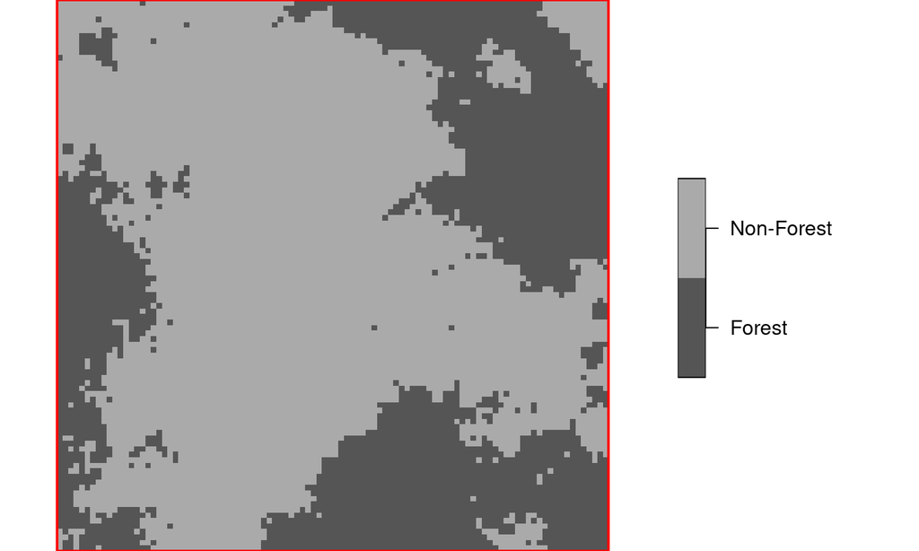

What is the proportion of \(p_F\) of forest in the area of interest (box)?

- Given we can plan the sampling, how should we do that?
- Given a sample has already been taken, what are our options to estimate \(p_F\)?

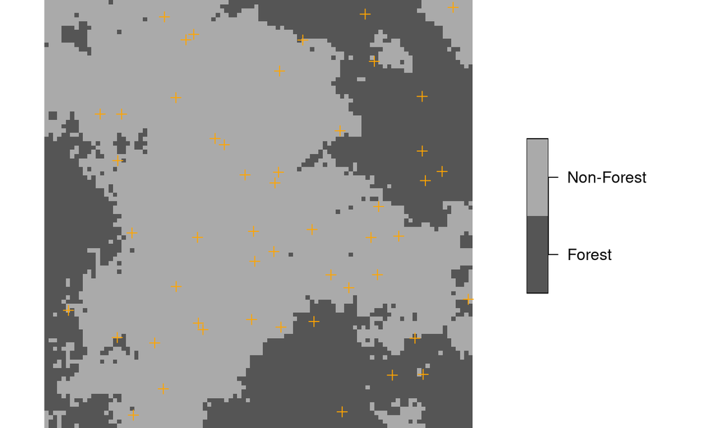

## 95% CI, design-based, simple random sampling

Sample mean (n = 50):

```r
(m = mean(v$f == "Forest"))
```

```
## [1] 0.22
```

95% CI using normal approximation (CLT, n large, \(m\) not too close to 0 or 1):

```r
se = sqrt(m * (1 - m) / n)
m + qnorm(c(.025,.975)) * se
```

```
## [1] 0.105 0.335
```

True mean (fraction over this whole single image):

```
## population_mean
##           0.357
```

## What does this confidence interval mean?

(we use small \(s\) for a fixed variable, capital \(S\) for a random variable)

- it is a design-based estimate: observations on a variable \(z\) at locations \(s\) are considered as coming from a random sampling process, \(z(S)\), with \(S\) randomly sampled from the area of interest \(A\): \(S\) is a random variable, \(z\) is fixed (as is \(z(s)\)).
- because of random sampling, *any* pair \(\{z(S_i),~z(S_j)\}\) are independent, and their separation distance \(|S_i-S_j|\) is again a random variable
- the CI means that **under repeated sampling** (using the same procedure), on average 95 out of 100 cases this CI will include the population parameter \(p_F\).

## Replicates: repeated sampling

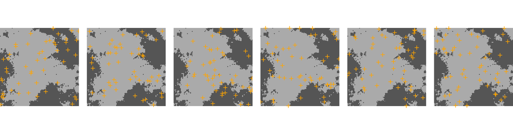

…

## CI coverage: repeated sampling

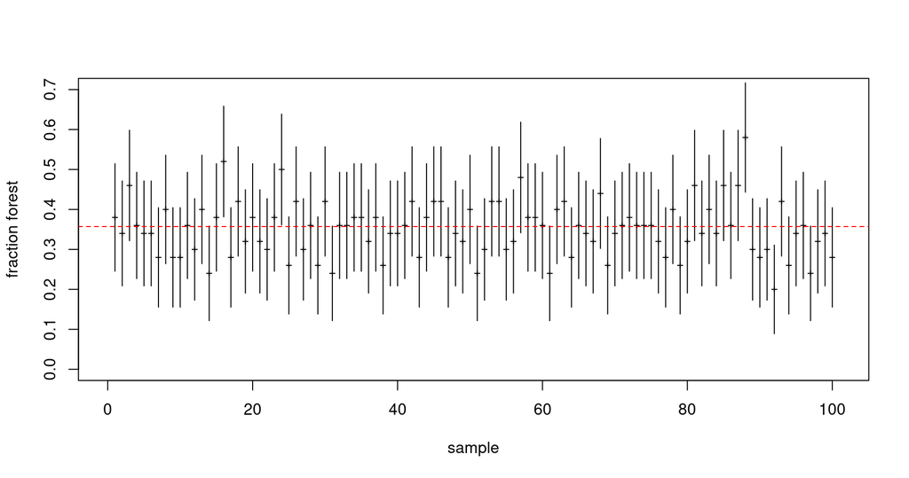

(red line: population mean 0.357)

## model-based 95% CI

- model-based, we assume \(z(s)\) to be a realisation (sample of size 1) of a superpopulation (random field) \(Z(s)\)
- we postulate (assume) a model, e.g. \(Z(s) = m + e(s)\), with \(m\) a spatial constant unknown mean (fixed effect), and \(e(s)\) a spatially correlated random variable (random effect)
- For stationary random fields, Correlation of \(Z(s_i)\) and \(Z(s_j)\) are assumed to be correlated as a function of distance: \(\mbox{Cov}(Z(s_i), Z(s_j)) = C(h)\), with \(h=|s_i-s_j|\)
- sampling strategy does “not” play a role: can be anything, but ignoring biases leads to disaster, as anywhere in statistics

## Estimating \(m\)?

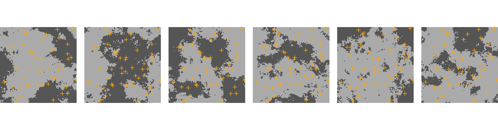

- the boxes show *independent* realisations of \(Z(s)\), *unconditional* to any measurements
- \(m\) is a property of the whole random field \(Z(s)\), not just the realisation at hand (unconditional to the observations)
- it is also in no way spatially restricted to the area of interest
- “true” \(m\) is 0.309 (parameter of generating process)

## Predicting \(Z(A)\)

- Model-based, \(s\) is no longer random so we can predict \(Z(s_0)\) by \(\hat{Z}(s_0)=\sum_{i=1}^n \lambda_i Z(s_i)\) (with \(\lambda_i\) the kriging weights) for *any* \(s_0\) (kriging interpolation): estimates *probability* of \(Z(s_0)\) being forest
- This means that we can also predict the area mean \(Z(A)=\frac{1}{|A|}\int_A Z(u)du\), e.g. using the mean of predictions over the area: \[\frac{1}{K}\sum_{j=1}^K \hat{Z}(s_j)\] this is the *block kriging* prediction; it comes with a block kriging standard error that takes all the correlations between the \(\hat{Z}(s_j)\) into account: block kriging deals with *change of support*

## Required: variogram

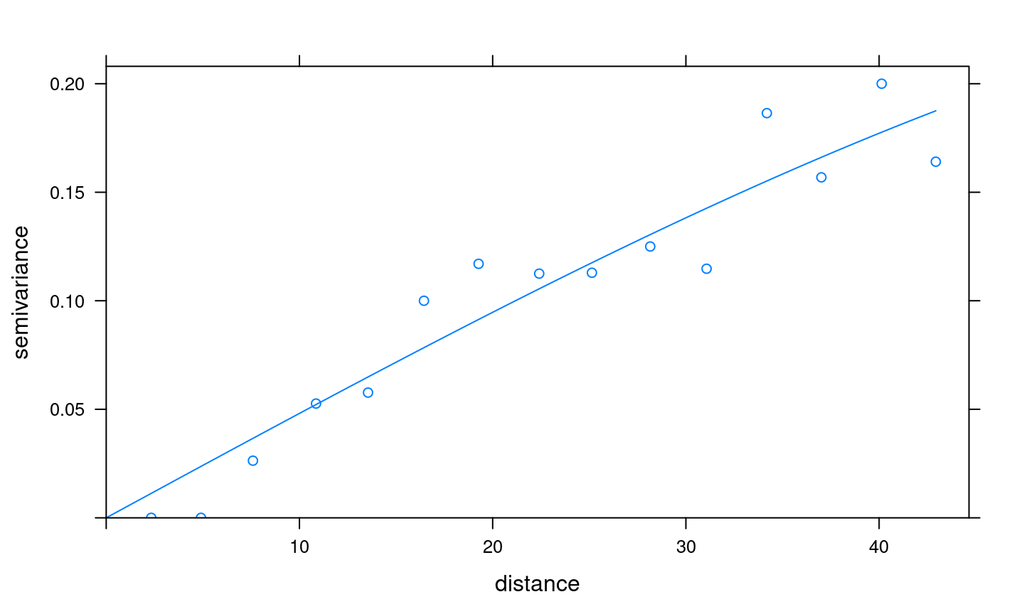

## Kriging predictions:

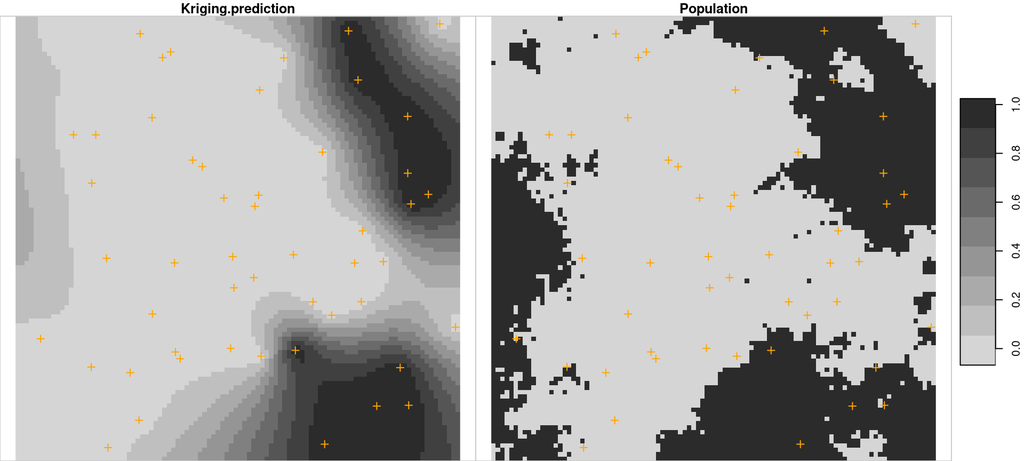

Left: predictions of \(\hat{p}(Z(s) = \mbox{"Forest"})\), Right: population

## Block kriging for the whole of \(A\)

Block kriging prediction:

```
## predicted_mean
##          0.234
```

```
## p.025 p.975
## 0.177 0.291
```

Compare to design-based mean estimate:

```
## estimated_mean
##           0.22
```

```
## p.025 p.975
## 0.105 0.335
```

## What does the block kriging CI refer to?

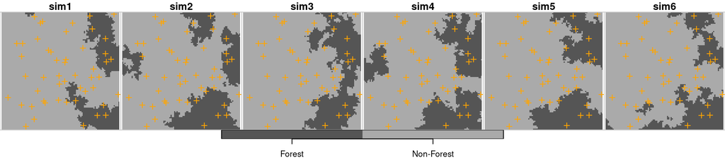

CI’s reflect averaging over the *conditional* random fields \(Z(s)|z(s_i),i=1.,,,.n\) that:

- have mean \(m\) and covariance \(C(h)\)
- are conditioned to (“obey the”) sample data, i.e. \(Z(s_i)=z(s_i)\) for all observations \(i\), but are otherwise independent

## Machine learning example

Model accuracy: 0.94 (Really?)

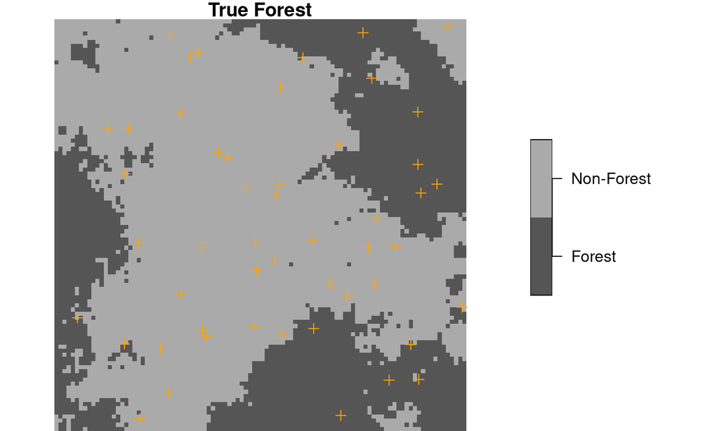

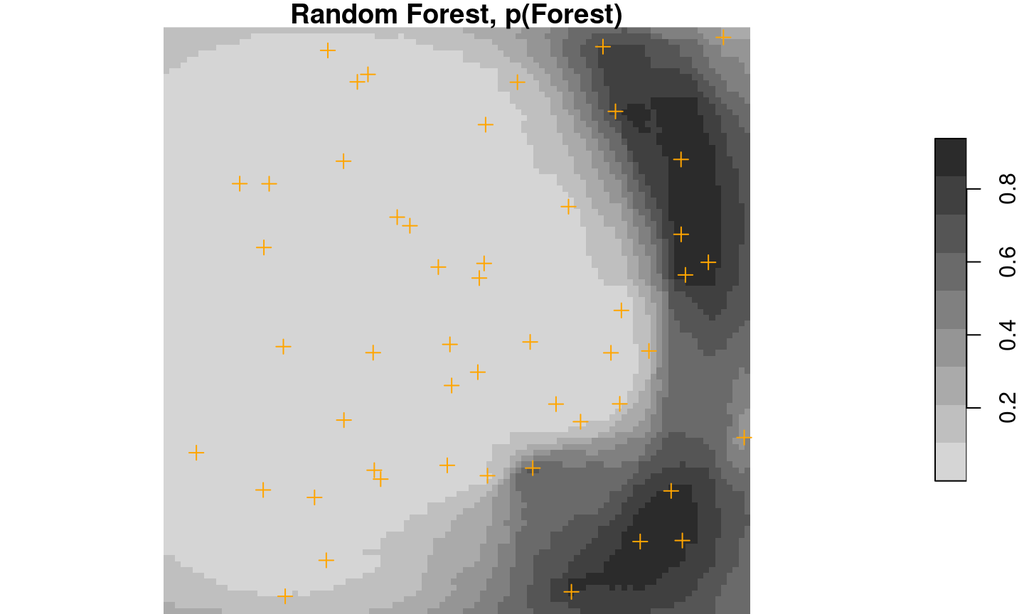

- How was the model validated?
- Area average of \(\hat{p}_F\): 0.231; fraction of pixels with \(\hat{p}_F > .5\): 0.244
- No sensible standard errors for area average estimates

## Comparison design-based / model-based

1. Design-based methods do not need a model, and are more robust: model-based approaches lean on an assumed model.
2. Design-based models are robust only if random sampling was used, and inclusion probabilities (sample weights) are known
3. Model-based approaches make no assumption about sampling, but also have no guard against biased sampling
4. Model-based approaches can make predictions for *any* location, and predict means over regions of *any* shape; design-based only estimate *averages* over the sampled region(s).
5. The probability statements differ: design-based CI’s refer to repeating the sampling procedure, model-based CI’s refer to (conditional) super-populations under a fixed sample.
6. The real fun starts when a design-based strategy is taken using a model-based *predicted* layer for stratification, and prediction errors are ignored.

## Why we use R

- R is a language that was [developed for data analysis](https://www.nytimes.com/2009/01/07/technology/business-computing/07program.html)
- All numbers and figures in these slides were generated by R (where the commands were mostly suppressed, to avoid clutter):
  - this makes them 100% reproducible, and
  - a source for further experimentation
  - literate programming helps explaining code, computation, and intention
  - source of slides is found [here](https://github.com/edzer/eo4statistics/blob/master/slides.Rmd)
  - copy-and-paste errors are ruled out
- R has a number (> 16K) of extension packages, many of them for spatial statistics, well maintained, well tested; best seen as an ecosystem.
- Installation of extension packages on a variety of hardware (Mac OSX, Windows, or Linux) is relatively painless.